# multivariate brms for F1 and F2

Xinyu Zhang

2024-27-12

# Reading in data

```r
df <- data.frame(read.csv("productionFullTable.csv"))


#change variables into correct data types
df$BB <- as.factor(df$BB)
df$Label <- as.factor(df$Label)
df$block <- as.factor(df$block)
df$gender <- as.factor(df$gender)
df$AF <- as.factor(df$AF)
df$subj <- as.character(df$subj)
df$seq <- as.numeric(df$seq)
df$F0Hz <- as.numeric(df$F0Hz)
df$F1Hz <- as.numeric(df$F1Hz)
df$F2Hz <- as.numeric(df$F2Hz)
df$F1Bark <- as.numeric(df$F1Bark)
df$F2Bark <- as.numeric(df$F2Bark)

#coding the reference level for contrasts
df$BB <- relevel(df$BB, ref = "NB") #non-bite-block group as reference

df$AF <- relevel(df$AF, ref = "AF") #regular auditory feedback group as reference

#df$Label <- relevel(df$Label, ref = "E") #vowel /E/ as reference because it is less affected by the bite block

df$block <- relevel(df$block, ref = "1") #block 1 as reference because it's the pretest

gender.contrast <- cbind (c (-0.5, +0.5)) # female = -0.5, male = +0.5
colnames (gender.contrast) <- c ("-F+M")
contrasts (df$gender) <- gender.contrast #it makes more sense to have the grand mean as reference level than having either gender. See the other html file for comparison

#same for vowel contrast, changing it to sum coding.
vowel.contrast <- cbind (c (-0.5, +0.5)) # E = -0.5, I = +0.5
colnames (vowel.contrast) <- c ("-E+I")
contrasts (df$Label) <- vowel.contrast



#showing the structure of the data table
library(dplyr)
summary(df)
```

```
##        X            fileName             subj               word
##  Min.   :   1.0   Length:2847        Length:2847        Length:2847
##  1st Qu.: 712.5   Class :character   Class :character   Class :character
##  Median :1424.0   Mode  :character   Mode  :character   Mode  :character
##  Mean   :1424.0
##  3rd Qu.:2135.5
##  Max.   :2847.0
##
##  block        seq        Label         F0Hz            F1Hz
##  1:952   Min.   : 0.00   E:1425   Min.   : 80.0   Min.   : 193.0
##  2:945   1st Qu.:13.00   I:1422   1st Qu.:206.0   1st Qu.: 429.0
##  4:950   Median :26.00            Median :231.0   Median : 493.0
##          Mean   :26.45            Mean   :224.2   Mean   : 516.8
##          3rd Qu.:40.00            3rd Qu.:255.0   3rd Qu.: 589.0
##          Max.   :53.00            Max.   :568.0   Max.   :1674.0
##                                   NA's   :3
##       F2Hz          F1Bark           F2Bark      gender    BB        AF
##  Min.   : 806   Min.   : 2.000   Min.   : 7.00   F:2383   NB:1380   AF:1477
##  1st Qu.:1726   1st Qu.: 4.000   1st Qu.:12.00   M: 464   BB:1467   MN:1370
##  Median :1940   Median : 5.000   Median :13.00
##  Mean   :1908   Mean   : 5.046   Mean   :12.49
##  3rd Qu.:2119   3rd Qu.: 6.000   3rd Qu.:13.00
##  Max.   :3209   Max.   :12.000   Max.   :16.00
##
##      F1erb            F2erb
##  Min.   : 5.215   Min.   :14.02
##  1st Qu.: 9.322   1st Qu.:20.55
##  Median :10.200   Median :21.66
##  Mean   :10.384   Mean   :21.38
##  3rd Qu.:11.388   3rd Qu.:22.54
##  Max.   :19.450   Max.   :25.85
##
```

#calculating mean F1 and mean F2 for reporting

```r
dfIm <- df %>% filter(Label == "I" & gender == "M")
mean(dfIm$F1Hz)
```

```
## [1] 369.8936
```

```r
mean(dfIm$F2Hz)
```

```
## [1] 1764.506
```

```r
dfIf <- df %>% filter(Label == "I" & gender == "F")
mean(dfIf$F1Hz)
```

```
## [1] 455.5105
```

```r
mean(dfIf$F2Hz)
```

```
## [1] 2053.946
```

```r
dfEm <- df %>% filter(Label == "E" & gender == "M")
mean(dfEm$F1Hz)
```

```
## [1] 497.8908
```

```r
mean(dfEm$F2Hz)
```

```
## [1] 1621.891
```

```r
dfEf <- df %>% filter(Label == "E" & gender == "F")
mean(dfEf$F1Hz)
```

```
## [1] 610.1764
```

```r
mean(dfEf$F2Hz)
```

```
## [1] 1846.155
```

# Basic multivariate

```r
#library(brms)

#mult1 <- bf(mvbind(F1Hz, F2Hz) ~ block * BB * AF* Label + gender + (1|p|subj) + (1|q|word)) + set_rescor(TRUE)

# "|p|" in between indicates that all varying effects of `subj` should be modeled as correlated (F1&F2 intercept per subject). Same with "|q|".

# "set_rescor=(TRUE)" indicates that the errors of F1 and F2 estimates are to be modeled as correlated

#fit1 <- brm(mult1, data = df, chains = 2, cores = 2, seed = 206) #setting seed for reproducibility
```

```r
#library(brms)

mult1 <- bf(mvbind(F1Hz, F2Hz) ~ block * BB * AF* Label + gender + (1+ Label|p|subj) + (1|q|word)) + set_rescor(TRUE)

# "|p|" in between indicates that all varying effects of `subj` should be modeled as correlated (F1&F2 intercept per subject). Same with "|q|".

# "set_rescor=(TRUE)" indicates that the errors of F1 and F2 estimates are to be modeled as correlated

fit1 <- brm(mult1, data = df, chains = 2, cores = 2, seed = 206) #setting seed for reproducibility
```

```
## WARNING: Rtools is required to build R packages, but is not currently installed.
##
## Please download and install the appropriate version of Rtools for 4.5.1 from
## https://cran.r-project.org/bin/windows/Rtools/.
```

```
## Trying to compile a simple C file
```

[output not shown]

```
## WARNING: Rtools is required to build R packages, but is not currently installed.
##
## Please download and install the appropriate version of Rtools for 4.5.1 from
## https://cran.r-project.org/bin/windows/Rtools/.
```

# summarizing the results

```r
#fit1 <- add_criterion(fit1, "loo")
summary(fit1)
```

```
##  Family: MV(gaussian, gaussian)
##   Links: mu = identity; sigma = identity
##          mu = identity; sigma = identity
## Formula: F1Hz ~ block * BB * AF * Label + gender + (1 + Label | p | subj) + (1 | q | word)
##          F2Hz ~ block * BB * AF * Label + gender + (1 + Label | p | subj) + (1 | q | word)
##    Data: df (Number of observations: 2847)
##   Draws: 2 chains, each with iter = 2000; warmup = 1000; thin = 1;
##          total post-warmup draws = 2000
##
## Multilevel Hyperparameters:
## ~subj (Number of levels: 54)
##                                    Estimate Est.Error l-95% CI u-95% CI Rhat
## sd(F1Hz_Intercept)                    56.35      5.78    46.69    69.16 1.00
## sd(F1Hz_LabelMEPI)                    55.42      6.02    44.64    68.36 1.00
## sd(F2Hz_Intercept)                   111.78     12.05    90.82   138.49 1.00
## sd(F2Hz_LabelMEPI)                    63.14      8.73    48.03    81.70 1.00
## cor(F1Hz_Intercept,F1Hz_LabelMEPI)    -0.69      0.09    -0.83    -0.50 1.00
## cor(F1Hz_Intercept,F2Hz_Intercept)     0.11      0.14    -0.15     0.38 1.00
## cor(F1Hz_LabelMEPI,F2Hz_Intercept)    -0.27      0.13    -0.53    -0.01 1.00
## cor(F1Hz_Intercept,F2Hz_LabelMEPI)    -0.14      0.15    -0.43     0.17 1.00
## cor(F1Hz_LabelMEPI,F2Hz_LabelMEPI)    -0.44      0.14    -0.68    -0.13 1.00
## cor(F2Hz_Intercept,F2Hz_LabelMEPI)     0.38      0.15     0.07     0.65 1.00
##                                    Bulk_ESS Tail_ESS
## sd(F1Hz_Intercept)                      778     1218
## sd(F1Hz_LabelMEPI)                     1131     1546
## sd(F2Hz_Intercept)                      878     1160
## sd(F2Hz_LabelMEPI)                      953     1458
## cor(F1Hz_Intercept,F1Hz_LabelMEPI)      931     1420
## cor(F1Hz_Intercept,F2Hz_Intercept)      643      571
## cor(F1Hz_LabelMEPI,F2Hz_Intercept)      755     1063
## cor(F1Hz_Intercept,F2Hz_LabelMEPI)     1154     1261
## cor(F1Hz_LabelMEPI,F2Hz_LabelMEPI)     1118     1540
## cor(F2Hz_Intercept,F2Hz_LabelMEPI)      871      486
##
## ~word (Number of levels: 6)
##                                    Estimate Est.Error l-95% CI u-95% CI Rhat
## sd(F1Hz_Intercept)                    19.43     11.37     7.80    52.32 1.00
## sd(F2Hz_Intercept)                   149.64     70.86    66.26   348.86 1.00
## cor(F1Hz_Intercept,F2Hz_Intercept)    -0.24      0.41    -0.88     0.61 1.00
##                                    Bulk_ESS Tail_ESS
```

[output cut: 105 more lines]

```
## F2Hz_block2:BBBB:AFMN:LabelMEPI     1223     1240
## F2Hz_block4:BBBB:AFMN:LabelMEPI     1163     1439
##
## Further Distributional Parameters:
##            Estimate Est.Error l-95% CI u-95% CI Rhat Bulk_ESS Tail_ESS
## sigma_F1Hz    69.19      0.95    67.41    71.06 1.00     2640     1234
## sigma_F2Hz   129.15      1.73   125.80   132.74 1.00     3335     1340
##
## Residual Correlations:
##                   Estimate Est.Error l-95% CI u-95% CI Rhat Bulk_ESS Tail_ESS
## rescor(F1Hz,F2Hz)     0.09      0.02     0.05     0.12 1.00     3000     1415
##
## Draws were sampled using sampling(NUTS). For each parameter, Bulk_ESS
## and Tail_ESS are effective sample size measures, and Rhat is the potential
## scale reduction factor on split chains (at convergence, Rhat = 1).
```

# posterior predictive check

```r
pp_check(fit1, resp = "F1Hz")
```

```
## Using 10 posterior draws for ppc type 'dens_overlay' by default.
```

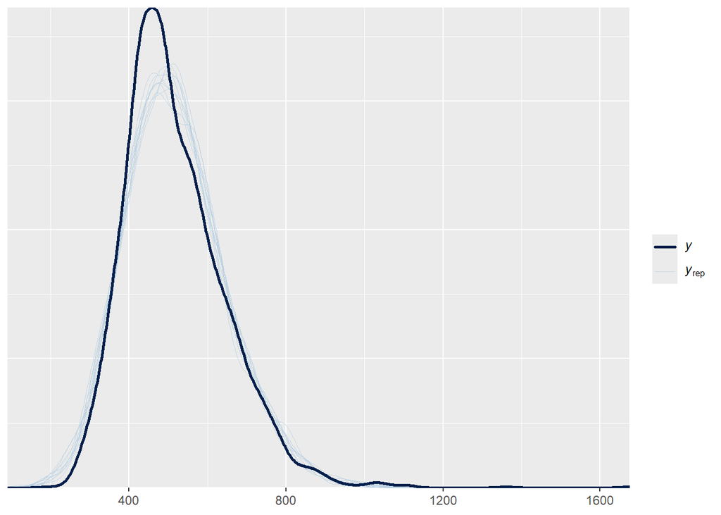

```r
pp_check(fit1, resp = "F2Hz")
```

```
## Using 10 posterior draws for ppc type 'dens_overlay' by default.
```

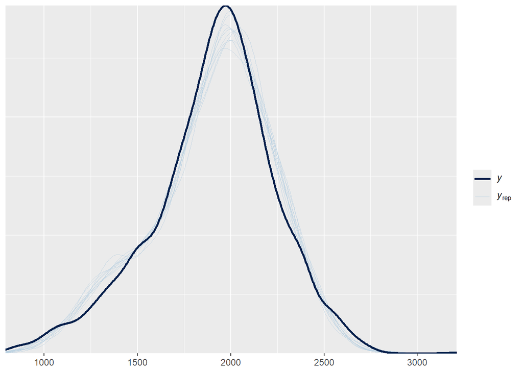

# Check $R^2$

```r
bayes_R2(fit1)
```

```
##         Estimate   Est.Error      Q2.5     Q97.5
## R2F1Hz 0.7090239 0.005188657 0.6984244 0.7185342
## R2F2Hz 0.8479332 0.002137611 0.8434941 0.8518906
```

The R squared looks really good :)

#### interaction plots

```r
library(ggplot2)
library(ggeffects)
dat <- predict_response(
  fit1,
  terms = c("AF", "BB"))
```

```
## Note: uncertainty of error terms are not taken into account. Consider
##   setting `interval` to "prediction". This will call `posterior_predict()`
##   instead of `posterior_epred()`.
```

```
## Back-transforming response variables is not carried out for
##   multivariate-response models.
```

```
## Ignoring unknown labels:
## • linetype : "BB"
## • shape : "BB"
```

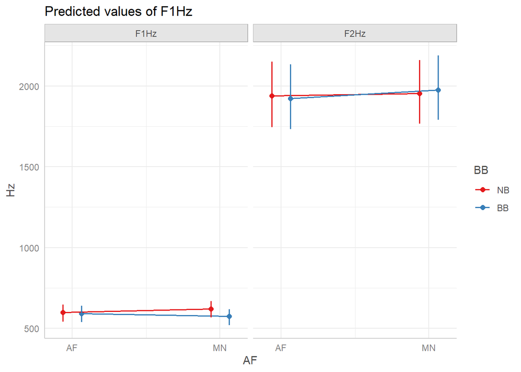

```r
 plot(dat,connect_lines = TRUE, one_plot = FALSE) + ylab("Hz")
```

```r
 #ggsave("AFxMN.png", plot = last_plot(), width = 9.5, height = 3.5, device = NULL, dpi = 600)
```

#### subset data to block 2 only, but only for the interaction plot at block 2

```r
library(brms)

mult2 <- bf(mvbind(F1Hz, F2Hz) ~ BB * AF* Label + gender + (1|p|subj) + (1|q|word)) + set_rescor(TRUE)

# "|p|" in between indicates that all varying effects of `subj` should be modeled as correlated (F1&F2 intercept per subject). Same with "|q|".

# "set_rescor=(TRUE)" indicates that the errors of F1 and F2 estimates are to be modeled as correlated

b2ef <- df %>% filter(block == "2")

fit2 <- brm(mult2, data = b2ef, chains = 2, cores = 2, seed = 2107) #setting seed for reproducibility
```

```
## WARNING: Rtools is required to build R packages, but is not currently installed.
##
## Please download and install the appropriate version of Rtools for 4.5.1 from
## https://cran.r-project.org/bin/windows/Rtools/.
```

```
## Trying to compile a simple C file
```

[output not shown]

```
## WARNING: Rtools is required to build R packages, but is not currently installed.
##
## Please download and install the appropriate version of Rtools for 4.5.1 from
## https://cran.r-project.org/bin/windows/Rtools/.
```

```r
dat <- predict_response(
  fit2,
  terms = c("BB", "AF"))
```

```
## Note: uncertainty of error terms are not taken into account. Consider
##   setting `interval` to "prediction". This will call `posterior_predict()`
##   instead of `posterior_epred()`.
```

```
## Back-transforming response variables is not carried out for
##   multivariate-response models.
```

```
## Ignoring unknown labels:
## • linetype : "AF"
## • shape : "AF"
```

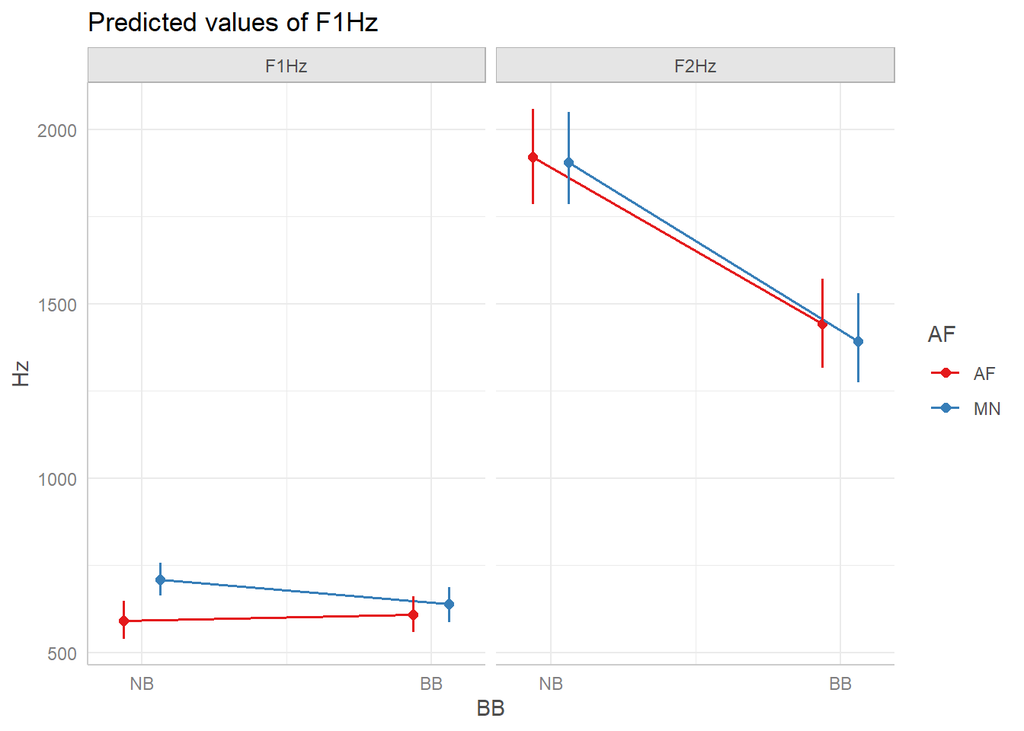

```r
 plot(dat,connect_lines = TRUE, one_plot = FALSE) + ylab("Hz")
```

```r
 ggsave("BBxAF.png", plot = last_plot(), width = 9.5, height = 3.5, device = NULL, dpi = 600)
```

```
## Ignoring unknown labels:
## • linetype : "AF"
## • shape : "AF"
```

```r
#mult1 <- bf(mvbind(F1Hz, F2Hz) ~ block * BB * AF* Label + gender + (1|p|subj) + (1|q|word)) + set_rescor(TRUE)

#fit1 <- brm(mult1, data = df, chains = 2, cores = 2, seed = 206)
#effect plot
#library(effects)
#plot(effect( "block * BB * AF", fit1))
```

## generating a LateX table of the coefficients

```r
library(kableExtra)
fixef(fit1)
```

```
##                                    Estimate  Est.Error        Q2.5        Q97.5
## F1Hz_Intercept                   472.710922  20.624316  432.182912  511.1452597
## F2Hz_Intercept                  1961.804957  74.312436 1804.237825 2120.8561063
## F1Hz_block2                       -2.874710   6.520299  -15.664695    9.3146175
## F1Hz_block4                        6.167329   6.555689   -7.165006   18.7637616
## F1Hz_BBBB                          2.070633  22.791858  -43.853859   45.8604642
## F1Hz_AFMN                          1.854804  23.571420  -44.515956   47.2611588
## F1Hz_LabelMEPI                  -145.115589  25.868599 -193.192289  -92.2139404
## F1Hz_genderMFPM                 -103.065984  14.411928 -132.586765  -75.0808207
## F1Hz_block2:BBBB                  30.844309   9.017109   13.969003   48.6793586
## F1Hz_block4:BBBB                  -9.774846   8.906236  -27.387989    7.6165954
## F1Hz_block2:AFMN                  80.352054   9.175500   62.237990   98.6063820
## F1Hz_block4:AFMN                 -14.670652   9.291096  -32.843813    3.5537010
## F1Hz_BBBB:AFMN                   -26.161852  32.326530  -89.233400   39.3014582
## F1Hz_block2:LabelMEPI              7.405309  12.687399  -16.726157   31.6652762
## F1Hz_block4:LabelMEPI             17.400825  12.879016   -7.796261   43.4365664
## F1Hz_BBBB:LabelMEPI               16.717580  24.812370  -30.685318   69.6375057
## F1Hz_AFMN:LabelMEPI              -43.034158  24.942674  -90.583622    7.5538180
## F1Hz_block2:BBBB:AFMN            -36.743293  13.052491  -61.990500  -11.3031254
## F1Hz_block4:BBBB:AFMN             18.714654  12.651722   -5.364986   44.5211484
## F1Hz_block2:BBBB:LabelMEPI        10.892387  17.366622  -24.267173   43.7989553
## F1Hz_block4:BBBB:LabelMEPI       -28.416704  17.727245  -64.646189    4.3780214
## F1Hz_block2:AFMN:LabelMEPI       -34.353085  17.989925  -70.696906    0.2095767
## F1Hz_block4:AFMN:LabelMEPI       -24.916688  18.098588  -60.897171    9.8984072
## F1Hz_BBBB:AFMN:LabelMEPI          30.377127  34.794247  -38.905771   97.2328684
## F1Hz_block2:BBBB:AFMN:LabelMEPI   27.087483  25.365455  -22.929557   76.2298428
## F1Hz_block4:BBBB:AFMN:LabelMEPI   32.286158  25.142014  -14.458251   81.6688291
## F2Hz_block2                      -18.258433  11.986785  -41.390699    4.8665463
## F2Hz_block4                      -36.059024  11.848656  -59.534374  -12.7513556
## F2Hz_BBBB                        -47.626399  43.929064 -132.014929   34.8213001
## F2Hz_AFMN                         10.681387  47.614879  -81.420230  101.5139424
## F2Hz_LabelMEPI                   252.723999 142.923087  -34.092738  511.6135059
## F2Hz_genderMFPM                 -212.397137  39.611399 -289.815074 -134.2359247
## F2Hz_block2:BBBB                -554.989768  16.377576 -586.879677 -522.9501796
## F2Hz_block4:BBBB                  10.192768  16.221916  -21.216032   42.3608358
## F2Hz_block2:AFMN                 -35.597477  16.786136  -68.497841   -5.4413571
## F2Hz_block4:AFMN                  31.391883  17.230058   -2.076473   65.9440721
## F2Hz_BBBB:AFMN                    67.951798  64.546834  -53.443717  194.8561044
## F2Hz_block2:LabelMEPI             15.642766  24.400214  -31.135758   62.5465570
## F2Hz_block4:LabelMEPI            -41.928071  24.726215  -90.347719    5.9930542
## F2Hz_BBBB:LabelMEPI              -65.272814  32.992397 -130.028243   -1.1355486
## F2Hz_AFMN:LabelMEPI               -6.540099  35.072381  -74.000928   62.3912852
## F2Hz_block2:BBBB:AFMN            -82.406929  22.993349 -126.278978  -36.1189633
## F2Hz_block4:BBBB:AFMN            -47.831781  23.587845  -93.701677   -1.1727576
## F2Hz_block2:BBBB:LabelMEPI      -190.805995  32.349455 -255.663372 -129.5641624
## F2Hz_block4:BBBB:LabelMEPI        37.021198  33.565773  -25.455931  103.2492279
## F2Hz_block2:AFMN:LabelMEPI       -35.409564  34.442867 -104.711831   30.0802413
## F2Hz_block4:AFMN:LabelMEPI        31.509513  33.860681  -32.312964   96.9254532
## F2Hz_BBBB:AFMN:LabelMEPI          62.364149  48.854011  -32.323233  154.8130718
## F2Hz_block2:BBBB:AFMN:LabelMEPI  -12.413600  47.320966 -109.362498   77.0089913
## F2Hz_block4:BBBB:AFMN:LabelMEPI  -23.962402  46.800672 -112.863673   66.4620288
```

```r
kable(data.frame(fixef(fit1)), digits = 2, "latex")
```

```r
#the results will only show up in the console, so run this line in the console, and change the column names as needed
```

# using an ex-Gaussian distribution as family instead of Gaussian

- (Gamma failed)
- (ex-gaussian did not mix at default iterations, changing the iteration count to 3000 or 4000 did not help)

```r
mult2 <- bf(mvbind(F1Hz, F2Hz) ~ block * BB * AF* Label + gender + (1|p|subj) + (1|q|word)) #set_rescor(TRUE) is not possible for exgaussian

#fit2 <- brm(mult2, data = df,family = exgaussian(link = "identity", link_sigma = "log", link_beta = "log"), chains = 2, cores = 2, iter = 4000)
```

```r
#fit2 <- add_criterion(fit2, "loo")
#summary(fit2)
```

R-hat is all bad, Bulk- and Tail-ESS are all too low.

Try adding priors to the first model instead

First let’s get the priors that the first model ended up using.

```r
get_prior(fit1)
```

| prior | class | coef | group | resp | dpar | nlpar | lb | ub | source |
| --- | --- | --- | --- | --- | --- | --- | --- | --- | --- |
|  | b |  |  |  |  |  |  |  | default |
|  | b |  |  | F1Hz |  |  |  |  | default |
|  | b | AFMN |  | F1Hz |  |  |  |  | default |
|  | b | AFMN:LabelMEPI |  | F1Hz |  |  |  |  | default |
|  | b | BBBB |  | F1Hz |  |  |  |  | default |
|  | b | BBBB:AFMN |  | F1Hz |  |  |  |  | default |
|  | b | BBBB:AFMN:LabelMEPI |  | F1Hz |  |  |  |  | default |
|  | b | BBBB:LabelMEPI |  | F1Hz |  |  |  |  | default |
|  | b | block2 |  | F1Hz |  |  |  |  | default |
|  | b | block2:AFMN |  | F1Hz |  |  |  |  | default |

[output cut: 62 more lines]

For the F1 intercept, the first model (fit1) used the prior `student_t(3,493,111.2)`.

```r
#mult1 <- bf(mvbind(F1Hz, F2Hz) ~ block * BB * AF* Label + gender + (1|p|subj) + (1|q|word)) + set_rescor(TRUE) #same as the first model
#fit3 <- brm(mult1, data = df,
            #prior = set_prior("student_t(3, 0, 250)", class = "sd", resp = "F1Hz", group = "subj", coef = "Intercept"),
            #chains = 2, cores = 2, seed = 655)
#summary(fit3)
```

Doing a new pp_check

```r
#pp_check(fit3, resp = "F1Hz")

#pp_check(fit3, resp = "F2Hz")
```

I do not see much difference in the fit from the first model with flat priors.

Checking R^2

```r
#bayes_R2(fit3)
```

R^2 did not improve.

Trying a different family with the prior included

```r
#fit4 <- brm(mult2, data = df,family = exgaussian(link = "identity", link_sigma = "log", link_beta = "log"),
            #prior = set_prior("student_t(3, 0, 250)", class = "sd", resp = "F1Hz", group = "subj", coef = "Intercept"),
            # chains = 2, cores = 2, iter = 4000)


#summary(fit4)
```

The R-hat and the bulk_ESS do not look good enough for the results to be reliable.

new pp check:

```r
#pp_check(fit4, resp = "F1Hz")

#pp_check(fit4, resp = "F2Hz")
```

The F1 fit looks a bit better (but it’s unreliable anyway). but F2 is worse.

## Trying to set a prior for the median in F1, according to data from Adank (2004), averaged across genders at 505Hz (because of the -0.5/+0.5 contrast coding here), which is not too different from the 493 in my data. (But still keeping the default family and default iteration count)

```r
fit5 <- brm(mult2, data = df,
            prior = set_prior("student_t(3, 505, 250)", class = "Intercept", resp = "F1Hz"),
            chains = 2, cores = 2, seed = 610)
```

```
## Setting 'rescor' to TRUE by default for this model
```

```
## WARNING: Rtools is required to build R packages, but is not currently installed.
##
## Please download and install the appropriate version of Rtools for 4.5.1 from
## https://cran.r-project.org/bin/windows/Rtools/.
```

```
## Trying to compile a simple C file
```

[output not shown]

```
## WARNING: Rtools is required to build R packages, but is not currently installed.
##
## Please download and install the appropriate version of Rtools for 4.5.1 from
## https://cran.r-project.org/bin/windows/Rtools/.
```

```r
summary(fit5)
```

```
##  Family: MV(gaussian, gaussian)
##   Links: mu = identity; sigma = identity
##          mu = identity; sigma = identity
## Formula: F1Hz ~ block * BB * AF * Label + gender + (1 | p | subj) + (1 | q | word)
##          F2Hz ~ block * BB * AF * Label + gender + (1 | p | subj) + (1 | q | word)
##    Data: df (Number of observations: 2847)
##   Draws: 2 chains, each with iter = 2000; warmup = 1000; thin = 1;
##          total post-warmup draws = 2000
##
## Multilevel Hyperparameters:
## ~subj (Number of levels: 54)
##                                    Estimate Est.Error l-95% CI u-95% CI Rhat
## sd(F1Hz_Intercept)                    57.71      6.27    46.96    71.00 1.00
## sd(F2Hz_Intercept)                   109.31     11.50    89.09   132.77 1.00
## cor(F1Hz_Intercept,F2Hz_Intercept)     0.13      0.15    -0.17     0.41 1.00
##                                    Bulk_ESS Tail_ESS
## sd(F1Hz_Intercept)                      691     1215
## sd(F2Hz_Intercept)                      838      927
## cor(F1Hz_Intercept,F2Hz_Intercept)      847     1154
##
## ~word (Number of levels: 6)
##                                    Estimate Est.Error l-95% CI u-95% CI Rhat
## sd(F1Hz_Intercept)                    18.79     10.37     7.61    43.80 1.00
## sd(F2Hz_Intercept)                   143.97     57.28    67.40   283.29 1.00
## cor(F1Hz_Intercept,F2Hz_Intercept)    -0.24      0.41    -0.86     0.62 1.00
##                                    Bulk_ESS Tail_ESS
## sd(F1Hz_Intercept)                      845     1053
## sd(F2Hz_Intercept)                      909     1082
## cor(F1Hz_Intercept,F2Hz_Intercept)     1410     1188
##
## Regression Coefficients:
##                                 Estimate Est.Error l-95% CI u-95% CI Rhat
## F1Hz_Intercept                    477.06     19.00   440.10   514.60 1.00
## F2Hz_Intercept                   1951.50     68.23  1819.57  2090.49 1.00
## F1Hz_block2                        -3.53      7.00   -17.42     9.91 1.00
## F1Hz_block4                         5.69      6.77    -7.92    18.35 1.00
## F1Hz_BBBB                          -2.76     23.17   -47.26    44.28 1.00
## F1Hz_AFMN                          -0.47     24.64   -47.72    48.87 1.00
## F1Hz_LabelMEPI                   -147.53     20.47  -188.60  -105.41 1.00
## F1Hz_genderMFPM                   -96.64     22.19  -140.04   -51.00 1.00
```

[output cut: 91 more lines]

```
## F2Hz_block2:BBBB:AFMN:LabelMEPI     1508     1529
## F2Hz_block4:BBBB:AFMN:LabelMEPI     1173     1646
##
## Further Distributional Parameters:
##            Estimate Est.Error l-95% CI u-95% CI Rhat Bulk_ESS Tail_ESS
## sigma_F1Hz    74.14      0.99    72.20    76.12 1.00     2607     1204
## sigma_F2Hz   132.56      1.80   129.10   136.20 1.00     1993     1355
##
## Residual Correlations:
##                   Estimate Est.Error l-95% CI u-95% CI Rhat Bulk_ESS Tail_ESS
## rescor(F1Hz,F2Hz)     0.04      0.02     0.00     0.08 1.00     1766     1100
##
## Draws were sampled using sampling(NUTS). For each parameter, Bulk_ESS
## and Tail_ESS are effective sample size measures, and Rhat is the potential
## scale reduction factor on split chains (at convergence, Rhat = 1).
```

pp check

```r
pp_check(fit5, resp = "F1Hz")
```

```
## Using 10 posterior draws for ppc type 'dens_overlay' by default.
```

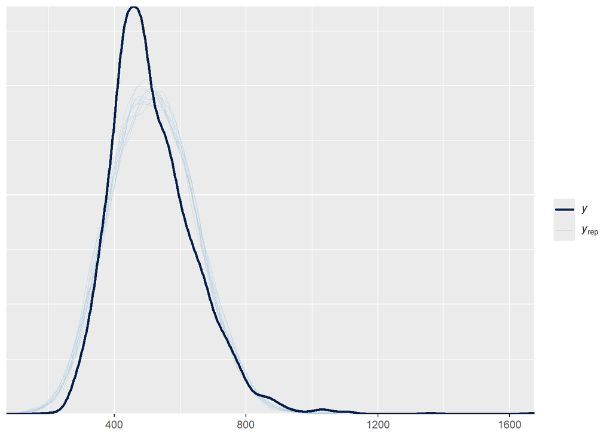

```r
pp_check(fit5, resp = "F2Hz")
```

```
## Using 10 posterior draws for ppc type 'dens_overlay' by default.
```

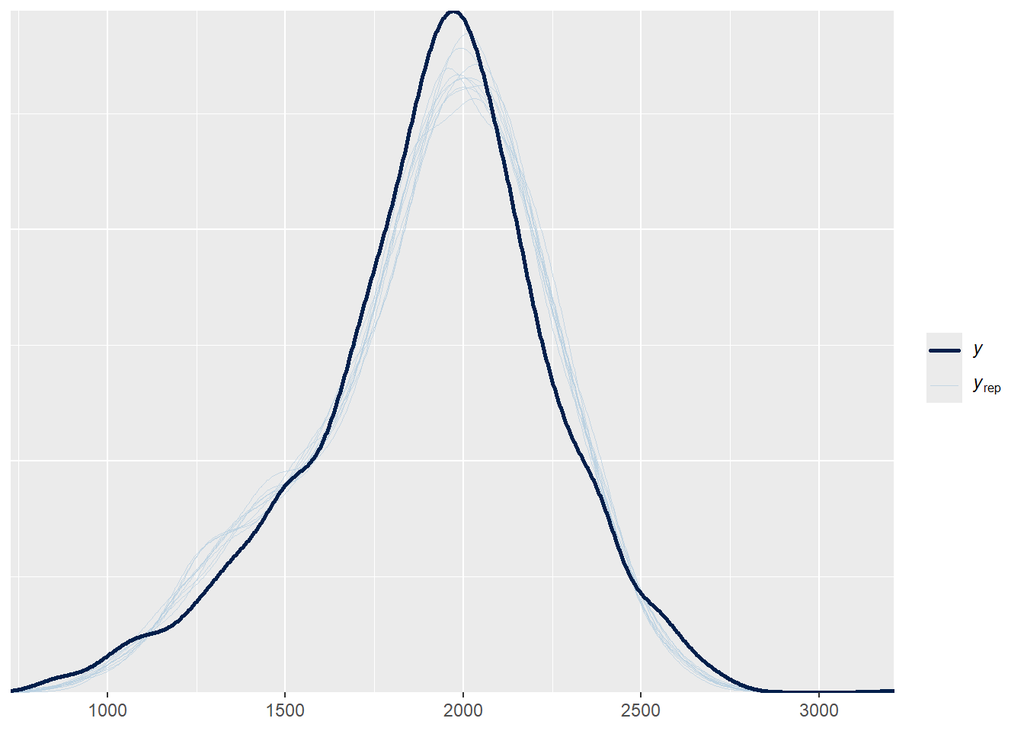

## basic multivariate but on ERB values

```r
library(brms)

multERB <- bf(mvbind(F1erb, F2erb) ~ block * BB * AF* Label + gender + (1 + Label|p|subj) + (1|q|word)) + set_rescor(TRUE)

# "|p|" in between indicates that all varying effects of `subj` should be modeled as correlated (F1&F2 intercept per subject). Same with "|q|".

# "set_rescor=(TRUE)" indicates that the errors of F1 and F2 estimates are to be modeled as correlated

fitERB <- brm(multERB, data = df, chains = 2, cores = 2, seed = 342) #setting seed for reproducibility
```

```
## WARNING: Rtools is required to build R packages, but is not currently installed.
##
## Please download and install the appropriate version of Rtools for 4.5.1 from
## https://cran.r-project.org/bin/windows/Rtools/.
```

```
## Trying to compile a simple C file
```

[output not shown]

```
## WARNING: Rtools is required to build R packages, but is not currently installed.
##
## Please download and install the appropriate version of Rtools for 4.5.1 from
## https://cran.r-project.org/bin/windows/Rtools/.
```

```r
summary(fitERB)
```

```
##  Family: MV(gaussian, gaussian)
##   Links: mu = identity; sigma = identity
##          mu = identity; sigma = identity
## Formula: F1erb ~ block * BB * AF * Label + gender + (1 + Label | p | subj) + (1 | q | word)
##          F2erb ~ block * BB * AF * Label + gender + (1 + Label | p | subj) + (1 | q | word)
##    Data: df (Number of observations: 2847)
##   Draws: 2 chains, each with iter = 2000; warmup = 1000; thin = 1;
##          total post-warmup draws = 2000
##
## Multilevel Hyperparameters:
## ~subj (Number of levels: 54)
##                                      Estimate Est.Error l-95% CI u-95% CI Rhat
## sd(F1erb_Intercept)                      0.69      0.07     0.56     0.84 1.01
## sd(F1erb_LabelMEPI)                      0.63      0.08     0.50     0.79 1.00
## sd(F2erb_Intercept)                      0.56      0.06     0.46     0.69 1.00
## sd(F2erb_LabelMEPI)                      0.27      0.04     0.20     0.36 1.00
## cor(F1erb_Intercept,F1erb_LabelMEPI)    -0.49      0.12    -0.69    -0.23 1.00
## cor(F1erb_Intercept,F2erb_Intercept)     0.05      0.14    -0.21     0.34 1.00
## cor(F1erb_LabelMEPI,F2erb_Intercept)    -0.26      0.14    -0.54     0.03 1.00
## cor(F1erb_Intercept,F2erb_LabelMEPI)    -0.11      0.17    -0.43     0.23 1.00
## cor(F1erb_LabelMEPI,F2erb_LabelMEPI)    -0.57      0.14    -0.80    -0.26 1.00
## cor(F2erb_Intercept,F2erb_LabelMEPI)     0.22      0.16    -0.12     0.52 1.00
##                                      Bulk_ESS Tail_ESS
## sd(F1erb_Intercept)                       570      804
## sd(F1erb_LabelMEPI)                       773     1169
## sd(F2erb_Intercept)                       589     1202
## sd(F2erb_LabelMEPI)                      1148     1407
## cor(F1erb_Intercept,F1erb_LabelMEPI)      907      980
## cor(F1erb_Intercept,F2erb_Intercept)      652     1243
## cor(F1erb_LabelMEPI,F2erb_Intercept)      610      844
## cor(F1erb_Intercept,F2erb_LabelMEPI)     1078     1320
## cor(F1erb_LabelMEPI,F2erb_LabelMEPI)     1186     1526
## cor(F2erb_Intercept,F2erb_LabelMEPI)     1222     1488
##
## ~word (Number of levels: 6)
##                                      Estimate Est.Error l-95% CI u-95% CI Rhat
## sd(F1erb_Intercept)                      0.24      0.17     0.09     0.67 1.01
## sd(F2erb_Intercept)                      0.69      0.31     0.31     1.52 1.00
## cor(F1erb_Intercept,F2erb_Intercept)    -0.29      0.42    -0.89     0.64 1.00
##                                      Bulk_ESS Tail_ESS
```

[output cut: 105 more lines]

```
## F2erb_block2:BBBB:AFMN:LabelMEPI     1266     1315
## F2erb_block4:BBBB:AFMN:LabelMEPI     1611     1508
##
## Further Distributional Parameters:
##             Estimate Est.Error l-95% CI u-95% CI Rhat Bulk_ESS Tail_ESS
## sigma_F1erb     0.82      0.01     0.80     0.84 1.00     2524     1533
## sigma_F2erb     0.71      0.01     0.69     0.73 1.00     2459     1319
##
## Residual Correlations:
##                     Estimate Est.Error l-95% CI u-95% CI Rhat Bulk_ESS Tail_ESS
## rescor(F1erb,F2erb)     0.02      0.02    -0.02     0.06 1.00     2193     1436
##
## Draws were sampled using sampling(NUTS). For each parameter, Bulk_ESS
## and Tail_ESS are effective sample size measures, and Rhat is the potential
## scale reduction factor on split chains (at convergence, Rhat = 1).
```

## Checking for sequence effect in bite block group:

```r
#subset to block 2, Esther's suggestion to cross AF and Seq, and Seq*Label, but not AF * Label
bb2<- df %>% filter(block == "2" , BB == "BB")

seqbb2c <- bf(mvbind(F1Hz, F2Hz) ~  (AF + Label) * seq + gender + (1 + Label|p|subj) + (1|q|word)) + set_rescor(TRUE)

fitSeqbb2c <- brm(seqbb2c, data = bb2, chains = 2, cores = 2, seed = 1706) #setting seed for reproducibility
```

```
## WARNING: Rtools is required to build R packages, but is not currently installed.
##
## Please download and install the appropriate version of Rtools for 4.5.1 from
## https://cran.r-project.org/bin/windows/Rtools/.
```

```
## Trying to compile a simple C file
```

[output not shown]

```
## WARNING: Rtools is required to build R packages, but is not currently installed.
##
## Please download and install the appropriate version of Rtools for 4.5.1 from
## https://cran.r-project.org/bin/windows/Rtools/.
```

```r
summary(fitSeqbb2c)
```

```
##  Family: MV(gaussian, gaussian)
##   Links: mu = identity; sigma = identity
##          mu = identity; sigma = identity
## Formula: F1Hz ~ (AF + Label) * seq + gender + (1 + Label | p | subj) + (1 | q | word)
##          F2Hz ~ (AF + Label) * seq + gender + (1 + Label | p | subj) + (1 | q | word)
##    Data: bb2 (Number of observations: 485)
##   Draws: 2 chains, each with iter = 2000; warmup = 1000; thin = 1;
##          total post-warmup draws = 2000
##
## Multilevel Hyperparameters:
## ~subj (Number of levels: 28)
##                                    Estimate Est.Error l-95% CI u-95% CI Rhat
## sd(F1Hz_Intercept)                    96.10     14.21    73.29   128.64 1.00
## sd(F1Hz_LabelMEPI)                    55.85     11.03    37.28    80.94 1.00
## sd(F2Hz_Intercept)                   146.07     23.21   108.71   201.97 1.00
## sd(F2Hz_LabelMEPI)                    20.06     14.28     1.01    53.78 1.00
## cor(F1Hz_Intercept,F1Hz_LabelMEPI)    -0.81      0.12    -0.97    -0.53 1.00
## cor(F1Hz_Intercept,F2Hz_Intercept)     0.38      0.16     0.03     0.65 1.00
## cor(F1Hz_LabelMEPI,F2Hz_Intercept)    -0.41      0.20    -0.75     0.01 1.01
## cor(F1Hz_Intercept,F2Hz_LabelMEPI)    -0.17      0.39    -0.84     0.61 1.00
## cor(F1Hz_LabelMEPI,F2Hz_LabelMEPI)     0.16      0.41    -0.68     0.85 1.00
## cor(F2Hz_Intercept,F2Hz_LabelMEPI)     0.17      0.42    -0.71     0.84 1.00
##                                    Bulk_ESS Tail_ESS
## sd(F1Hz_Intercept)                      721     1009
## sd(F1Hz_LabelMEPI)                     1162     1592
## sd(F2Hz_Intercept)                      964     1252
## sd(F2Hz_LabelMEPI)                     1246     1256
## cor(F1Hz_Intercept,F1Hz_LabelMEPI)      950     1270
## cor(F1Hz_Intercept,F2Hz_Intercept)      908     1181
## cor(F1Hz_LabelMEPI,F2Hz_Intercept)      466      900
## cor(F1Hz_Intercept,F2Hz_LabelMEPI)     2616     1462
## cor(F1Hz_LabelMEPI,F2Hz_LabelMEPI)     2346     1561
## cor(F2Hz_Intercept,F2Hz_LabelMEPI)     2663     1545
##
## ~word (Number of levels: 6)
##                                    Estimate Est.Error l-95% CI u-95% CI Rhat
## sd(F1Hz_Intercept)                    16.77     13.34     1.36    50.73 1.01
## sd(F2Hz_Intercept)                    18.13     17.27     0.61    61.68 1.00
## cor(F1Hz_Intercept,F2Hz_Intercept)     0.07      0.57    -0.93     0.95 1.00
##                                    Bulk_ESS Tail_ESS
```

[output cut: 18 more lines]

```
## F2Hz_AFMN:seq         -1.84      0.90    -3.65    -0.10 1.00     2869     1613
## F2Hz_LabelMEPI:seq     0.42      0.86    -1.22     2.16 1.00     2562     1455
##
## Further Distributional Parameters:
##            Estimate Est.Error l-95% CI u-95% CI Rhat Bulk_ESS Tail_ESS
## sigma_F1Hz    75.98      2.54    71.31    81.07 1.00     2302     1560
## sigma_F2Hz   145.82      5.17   135.62   156.44 1.00     2859     1448
##
## Residual Correlations:
##                   Estimate Est.Error l-95% CI u-95% CI Rhat Bulk_ESS Tail_ESS
## rescor(F1Hz,F2Hz)     0.22      0.04     0.13     0.30 1.00     3149     1728
##
## Draws were sampled using sampling(NUTS). For each parameter, Bulk_ESS
## and Tail_ESS are effective sample size measures, and Rhat is the potential
## scale reduction factor on split chains (at convergence, Rhat = 1).
```

```r
library(kableExtra)
library(lme4)
kable(data.frame(fixef(fitSeqbb2c)), digits = 2, "latex")
```

```r
#control group
#subset to block 2, Esther's suggestion to cross AF and Seq, and Seq*Label, but not AF * Label

nb2<- df %>% filter(block == "2" , BB == "NB")

seqnb2c <- bf(mvbind(F1Hz, F2Hz) ~  (AF + Label) * seq + gender + (1 + Label|p|subj) + (1|q|word)) + set_rescor(TRUE)

fitSeqnb2c <- brm(seqbb2c, data = nb2, chains = 2, cores = 2, seed = 1706) #setting seed for reproducibility
```

```
## WARNING: Rtools is required to build R packages, but is not currently installed.
##
## Please download and install the appropriate version of Rtools for 4.5.1 from
## https://cran.r-project.org/bin/windows/Rtools/.
```

```
## Trying to compile a simple C file
```

[output not shown]

```
## WARNING: Rtools is required to build R packages, but is not currently installed.
##
## Please download and install the appropriate version of Rtools for 4.5.1 from
## https://cran.r-project.org/bin/windows/Rtools/.
```

```r
summary(fitSeqnb2c)
```

```
##  Family: MV(gaussian, gaussian)
##   Links: mu = identity; sigma = identity
##          mu = identity; sigma = identity
## Formula: F1Hz ~ (AF + Label) * seq + gender + (1 + Label | p | subj) + (1 | q | word)
##          F2Hz ~ (AF + Label) * seq + gender + (1 + Label | p | subj) + (1 | q | word)
##    Data: nb2 (Number of observations: 460)
##   Draws: 2 chains, each with iter = 2000; warmup = 1000; thin = 1;
##          total post-warmup draws = 2000
##
## Multilevel Hyperparameters:
## ~subj (Number of levels: 26)
##                                    Estimate Est.Error l-95% CI u-95% CI Rhat
## sd(F1Hz_Intercept)                    76.79     13.17    56.25   108.64 1.00
## sd(F1Hz_LabelMEPI)                    85.11     13.16    63.84   115.02 1.00
## sd(F2Hz_Intercept)                   131.45     22.15    96.46   183.83 1.00
## sd(F2Hz_LabelMEPI)                    95.87     17.84    65.76   136.03 1.00
## cor(F1Hz_Intercept,F1Hz_LabelMEPI)    -0.75      0.11    -0.91    -0.49 1.00
## cor(F1Hz_Intercept,F2Hz_Intercept)     0.05      0.21    -0.38     0.43 1.00
## cor(F1Hz_LabelMEPI,F2Hz_Intercept)    -0.15      0.22    -0.54     0.27 1.00
## cor(F1Hz_Intercept,F2Hz_LabelMEPI)    -0.12      0.21    -0.51     0.29 1.00
## cor(F1Hz_LabelMEPI,F2Hz_LabelMEPI)    -0.36      0.19    -0.70     0.06 1.00
## cor(F2Hz_Intercept,F2Hz_LabelMEPI)     0.29      0.20    -0.13     0.66 1.00
##                                    Bulk_ESS Tail_ESS
## sd(F1Hz_Intercept)                      494      878
## sd(F1Hz_LabelMEPI)                      828     1325
## sd(F2Hz_Intercept)                      657      940
## sd(F2Hz_LabelMEPI)                     1051     1357
## cor(F1Hz_Intercept,F1Hz_LabelMEPI)      718      957
## cor(F1Hz_Intercept,F2Hz_Intercept)      759     1045
## cor(F1Hz_LabelMEPI,F2Hz_Intercept)      699      847
## cor(F1Hz_Intercept,F2Hz_LabelMEPI)     1194     1310
## cor(F1Hz_LabelMEPI,F2Hz_LabelMEPI)     1120     1366
## cor(F2Hz_Intercept,F2Hz_LabelMEPI)     1156     1276
##
## ~word (Number of levels: 6)
##                                    Estimate Est.Error l-95% CI u-95% CI Rhat
## sd(F1Hz_Intercept)                    18.43     11.92     5.02    47.51 1.00
## sd(F2Hz_Intercept)                   156.82     59.70    78.41   300.63 1.00
## cor(F1Hz_Intercept,F2Hz_Intercept)    -0.22      0.41    -0.87     0.64 1.00
##                                    Bulk_ESS Tail_ESS
```

[output cut: 18 more lines]

```
## F2Hz_AFMN:seq          0.82      0.66    -0.48     2.09 1.00     2211     1628
## F2Hz_LabelMEPI:seq    -0.10      0.65    -1.39     1.21 1.00     2990     1686
##
## Further Distributional Parameters:
##            Estimate Est.Error l-95% CI u-95% CI Rhat Bulk_ESS Tail_ESS
## sigma_F1Hz    54.96      1.98    51.28    59.14 1.00     2810     1296
## sigma_F2Hz    97.57      3.35    91.04   104.36 1.00     2884     1522
##
## Residual Correlations:
##                   Estimate Est.Error l-95% CI u-95% CI Rhat Bulk_ESS Tail_ESS
## rescor(F1Hz,F2Hz)    -0.19      0.05    -0.29    -0.10 1.00     3335     1266
##
## Draws were sampled using sampling(NUTS). For each parameter, Bulk_ESS
## and Tail_ESS are effective sample size measures, and Rhat is the potential
## scale reduction factor on split chains (at convergence, Rhat = 1).
```

```r
kable(data.frame(fixef(fitSeqnb2c)), digits = 2, "latex")
```

plotting seq effect

```r
library(ggplot2)
library(ggeffects)
library(patchwork)
datbb2 <- predict_response(
  fitSeqbb2c,
  terms = c("seq", "Label"))
```

```
## Note: uncertainty of error terms are not taken into account. Consider
##   setting `interval` to "prediction". This will call `posterior_predict()`
##   instead of `posterior_epred()`.
```

```
## Back-transforming response variables is not carried out for
##   multivariate-response models.
```

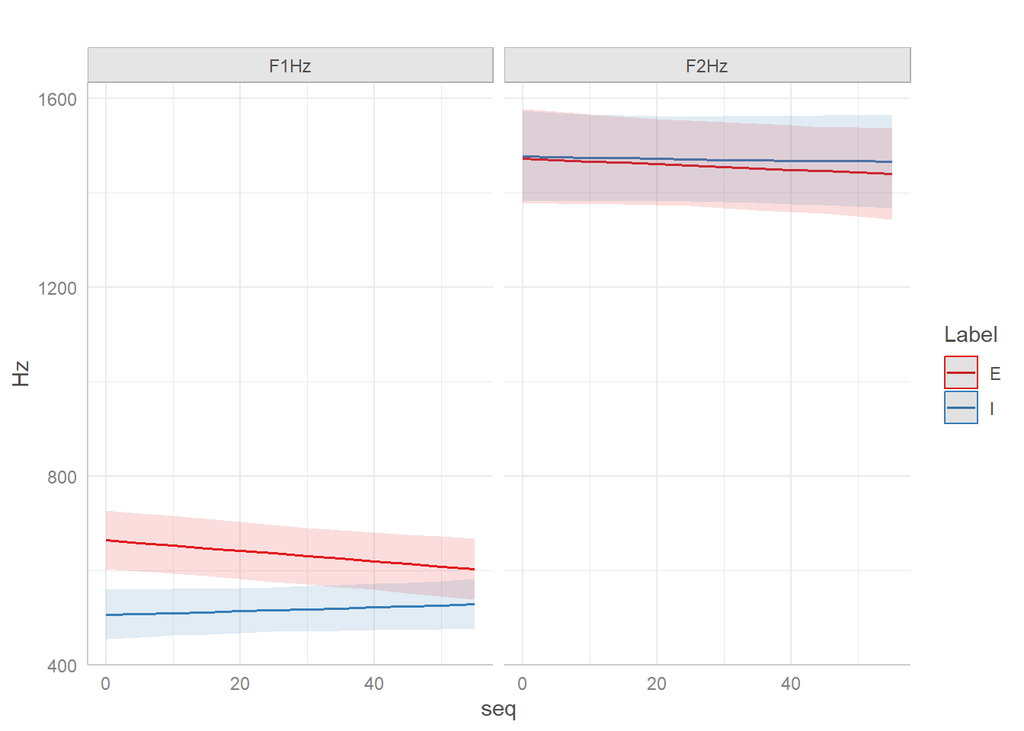

```r
#b2 <-
  plot(datbb2,connect_lines = TRUE, one_plot = FALSE) + ylab("Hz") +ggtitle("")
```

```r
#datnb2 <- predict_response(
  #fitSeqnb2c,
  #terms = c("seq", "Label"))
#n2 <-
  #plot(datnb2,connect_lines = TRUE, one_plot = FALSE) + ylab("Hz") +ggtitle("control group during test")

#b2+n2


ggsave("seqBlock2BB.png", plot = last_plot(), width = 9.5, height = 5.5, device = NULL, dpi = 600)
```

### posttest: Esther’s suggestion to cross AF and Seq, and Seq * Label, but not AF * Label

```r
#subset to block 4, Esther's suggestion to cross AF and Seq, and Seq*Label, but not AF * Label
bb4<- df %>% filter(block == "4" , BB == "BB")

seqbb4p <- bf(mvbind(F1Hz, F2Hz) ~  (AF + Label) * seq + gender + (1 + Label|p|subj) + (1|q|word)) + set_rescor(TRUE)

fitSeqbb4p <- brm(seqbb4p, data = bb4, chains = 2, cores = 2, seed = 1722) #setting seed for reproducibility
```

```
## WARNING: Rtools is required to build R packages, but is not currently installed.
##
## Please download and install the appropriate version of Rtools for 4.5.1 from
## https://cran.r-project.org/bin/windows/Rtools/.
```

```
## Trying to compile a simple C file
```

[output not shown]

```
## WARNING: Rtools is required to build R packages, but is not currently installed.
##
## Please download and install the appropriate version of Rtools for 4.5.1 from
## https://cran.r-project.org/bin/windows/Rtools/.
```

```r
summary(fitSeqbb4p)
```

```
##  Family: MV(gaussian, gaussian)
##   Links: mu = identity; sigma = identity
##          mu = identity; sigma = identity
## Formula: F1Hz ~ (AF + Label) * seq + gender + (1 + Label | p | subj) + (1 | q | word)
##          F2Hz ~ (AF + Label) * seq + gender + (1 + Label | p | subj) + (1 | q | word)
##    Data: bb4 (Number of observations: 488)
##   Draws: 2 chains, each with iter = 2000; warmup = 1000; thin = 1;
##          total post-warmup draws = 2000
##
## Multilevel Hyperparameters:
## ~subj (Number of levels: 28)
##                                    Estimate Est.Error l-95% CI u-95% CI Rhat
## sd(F1Hz_Intercept)                    44.84      6.76    33.40    60.19 1.00
## sd(F1Hz_LabelMEPI)                    74.87     11.22    56.60   101.02 1.00
## sd(F2Hz_Intercept)                   115.78     17.95    86.80   156.24 1.00
## sd(F2Hz_LabelMEPI)                    82.37     15.98    54.36   116.12 1.00
## cor(F1Hz_Intercept,F1Hz_LabelMEPI)    -0.54      0.16    -0.79    -0.19 1.00
## cor(F1Hz_Intercept,F2Hz_Intercept)     0.20      0.19    -0.19     0.54 1.00
## cor(F1Hz_LabelMEPI,F2Hz_Intercept)    -0.40      0.16    -0.68    -0.05 1.00
## cor(F1Hz_Intercept,F2Hz_LabelMEPI)    -0.49      0.19    -0.80    -0.07 1.01
## cor(F1Hz_LabelMEPI,F2Hz_LabelMEPI)     0.01      0.21    -0.39     0.42 1.00
## cor(F2Hz_Intercept,F2Hz_LabelMEPI)     0.41      0.21    -0.03     0.76 1.00
##                                    Bulk_ESS Tail_ESS
## sd(F1Hz_Intercept)                      561      935
## sd(F1Hz_LabelMEPI)                      770     1214
## sd(F2Hz_Intercept)                      854     1222
## sd(F2Hz_LabelMEPI)                      990     1563
## cor(F1Hz_Intercept,F1Hz_LabelMEPI)      676      938
## cor(F1Hz_Intercept,F2Hz_Intercept)      725     1106
## cor(F1Hz_LabelMEPI,F2Hz_Intercept)      702      961
## cor(F1Hz_Intercept,F2Hz_LabelMEPI)      920     1207
## cor(F1Hz_LabelMEPI,F2Hz_LabelMEPI)     1346     1531
## cor(F2Hz_Intercept,F2Hz_LabelMEPI)     1288     1613
##
## ~word (Number of levels: 6)
##                                    Estimate Est.Error l-95% CI u-95% CI Rhat
## sd(F1Hz_Intercept)                    26.10     14.00    10.63    62.78 1.00
## sd(F2Hz_Intercept)                   165.65     61.69    81.70   313.98 1.00
## cor(F1Hz_Intercept,F2Hz_Intercept)    -0.42      0.38    -0.92     0.41 1.00
##                                    Bulk_ESS Tail_ESS
```

[output cut: 18 more lines]

```
## F2Hz_AFMN:seq          0.43      0.65    -0.87     1.68 1.00     2187     1318
## F2Hz_LabelMEPI:seq     0.03      0.65    -1.24     1.35 1.00     3179     1131
##
## Further Distributional Parameters:
##            Estimate Est.Error l-95% CI u-95% CI Rhat Bulk_ESS Tail_ESS
## sigma_F1Hz    47.77      1.61    44.73    50.99 1.00     2136     1357
## sigma_F2Hz   104.71      3.53    98.10   111.59 1.00     2571     1655
##
## Residual Correlations:
##                   Estimate Est.Error l-95% CI u-95% CI Rhat Bulk_ESS Tail_ESS
## rescor(F1Hz,F2Hz)    -0.05      0.05    -0.15     0.04 1.00     2725     1228
##
## Draws were sampled using sampling(NUTS). For each parameter, Bulk_ESS
## and Tail_ESS are effective sample size measures, and Rhat is the potential
## scale reduction factor on split chains (at convergence, Rhat = 1).
```

```r
kable(data.frame(fixef(fitSeqbb4p)), digits = 2, "latex")
```

```r
#control group
#subset to block 4, Esther's suggestion to cross AF and Seq, and Seq*Label, but not AF * Label
nb4<- df %>% filter(block == "4" , BB == "NB")

seqnb4c <- bf(mvbind(F1Hz, F2Hz) ~  (AF + Label) * seq + gender + (1 + Label|p|subj) + (1|q|word)) + set_rescor(TRUE)

fitSeqnb4c <- brm(seqnb4c, data = nb4, chains = 2, cores = 2, seed = 1722) #setting seed for reproducibility
```

```
## WARNING: Rtools is required to build R packages, but is not currently installed.
##
## Please download and install the appropriate version of Rtools for 4.5.1 from
## https://cran.r-project.org/bin/windows/Rtools/.
```

```
## Trying to compile a simple C file
```

[output not shown]

```
## WARNING: Rtools is required to build R packages, but is not currently installed.
##
## Please download and install the appropriate version of Rtools for 4.5.1 from
## https://cran.r-project.org/bin/windows/Rtools/.
```

```r
summary(fitSeqnb4c)
```

```
##  Family: MV(gaussian, gaussian)
##   Links: mu = identity; sigma = identity
##          mu = identity; sigma = identity
## Formula: F1Hz ~ (AF + Label) * seq + gender + (1 + Label | p | subj) + (1 | q | word)
##          F2Hz ~ (AF + Label) * seq + gender + (1 + Label | p | subj) + (1 | q | word)
##    Data: nb4 (Number of observations: 462)
##   Draws: 2 chains, each with iter = 2000; warmup = 1000; thin = 1;
##          total post-warmup draws = 2000
##
## Multilevel Hyperparameters:
## ~subj (Number of levels: 26)
##                                    Estimate Est.Error l-95% CI u-95% CI Rhat
## sd(F1Hz_Intercept)                    63.56     10.93    45.74    88.14 1.00
## sd(F1Hz_LabelMEPI)                    74.25     13.45    52.30   104.24 1.00
## sd(F2Hz_Intercept)                   142.29     23.22   105.47   194.70 1.00
## sd(F2Hz_LabelMEPI)                    86.98     16.93    60.07   124.22 1.00
## cor(F1Hz_Intercept,F1Hz_LabelMEPI)    -0.20      0.22    -0.59     0.27 1.00
## cor(F1Hz_Intercept,F2Hz_Intercept)     0.00      0.21    -0.40     0.39 1.00
## cor(F1Hz_LabelMEPI,F2Hz_Intercept)    -0.12      0.22    -0.52     0.32 1.00
## cor(F1Hz_Intercept,F2Hz_LabelMEPI)    -0.04      0.22    -0.46     0.37 1.00
## cor(F1Hz_LabelMEPI,F2Hz_LabelMEPI)    -0.55      0.19    -0.86    -0.13 1.00
## cor(F2Hz_Intercept,F2Hz_LabelMEPI)     0.34      0.20    -0.07     0.69 1.00
##                                    Bulk_ESS Tail_ESS
## sd(F1Hz_Intercept)                      715     1236
## sd(F1Hz_LabelMEPI)                      917     1523
## sd(F2Hz_Intercept)                      933     1373
## sd(F2Hz_LabelMEPI)                     1373     1527
## cor(F1Hz_Intercept,F1Hz_LabelMEPI)      796     1084
## cor(F1Hz_Intercept,F2Hz_Intercept)      831     1161
## cor(F1Hz_LabelMEPI,F2Hz_Intercept)      656     1020
## cor(F1Hz_Intercept,F2Hz_LabelMEPI)     1228     1480
## cor(F1Hz_LabelMEPI,F2Hz_LabelMEPI)     1038     1233
## cor(F2Hz_Intercept,F2Hz_LabelMEPI)     1394     1550
##
## ~word (Number of levels: 6)
##                                    Estimate Est.Error l-95% CI u-95% CI Rhat
## sd(F1Hz_Intercept)                    24.43     17.42     5.80    68.37 1.00
## sd(F2Hz_Intercept)                   157.82     67.08    77.73   337.21 1.00
## cor(F1Hz_Intercept,F2Hz_Intercept)    -0.06      0.43    -0.81     0.74 1.00
##                                    Bulk_ESS Tail_ESS
```

[output cut: 18 more lines]

```
## F2Hz_AFMN:seq         -0.70      0.56    -1.77     0.45 1.00     1844     1660
## F2Hz_LabelMEPI:seq     0.94      0.59    -0.20     2.11 1.00     3229     1457
##
## Further Distributional Parameters:
##            Estimate Est.Error l-95% CI u-95% CI Rhat Bulk_ESS Tail_ESS
## sigma_F1Hz    71.16      2.50    66.68    76.45 1.00     2728     1544
## sigma_F2Hz    92.27      3.29    85.99    98.90 1.00     3101     1439
##
## Residual Correlations:
##                   Estimate Est.Error l-95% CI u-95% CI Rhat Bulk_ESS Tail_ESS
## rescor(F1Hz,F2Hz)     0.22      0.05     0.12     0.31 1.00     2795     1168
##
## Draws were sampled using sampling(NUTS). For each parameter, Bulk_ESS
## and Tail_ESS are effective sample size measures, and Rhat is the potential
## scale reduction factor on split chains (at convergence, Rhat = 1).
```

```r
kable(data.frame(fixef(fitSeqnb4c)), digits = 2, "latex")
```

[output not shown]

plotting seq effect

```r
datb4 <- predict_response(
  fitSeqbb4p,
  terms = c("seq", "Label"))
```

```
## Note: uncertainty of error terms are not taken into account. Consider
##   setting `interval` to "prediction". This will call `posterior_predict()`
##   instead of `posterior_epred()`.
```

```
## Back-transforming response variables is not carried out for
##   multivariate-response models.
```

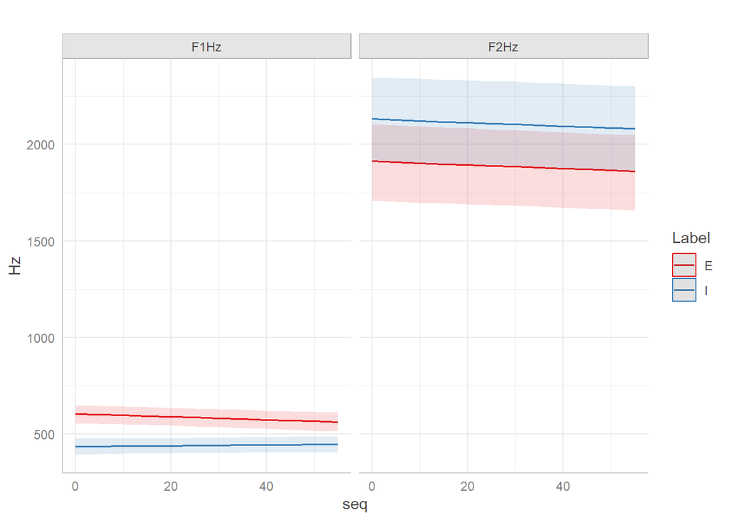

```r
 b4 <- plot(datb4,connect_lines = TRUE, one_plot = TRUE) + ylab("Hz")+ggtitle("")

#datnb4 <- predict_response(
  #fitSeqnb4c,
  #terms = c("seq", "Label"))
 #nb4 <- plot(datnb4,connect_lines = TRUE, one_plot = TRUE) + ylab("Hz")+ggtitle("control group at posttest")

 b4 #+ nb4
```

```r
ggsave("seqBlock4BB.png", plot = last_plot(), width = 9.5, height = 5.5, device = NULL, dpi = 600)
```